# Snakes & Ladders Analysis

Neto & Silva

March 2017

```r
library(readr)
library(dplyr)
library(ggplot2)
```

Let’s read the data with all the statistics:

```r
read_csv2("../stats/game.stats.csv") %>%
  mutate(int.rule = factor(int.rule)) %>%   # convert rule descriptions to factors
  mutate(end.rule = factor(end.rule)) -> d
```

## WIN criterion

The WIN criterion deals with how balanced the variants are, concerning winner percentages for each player.

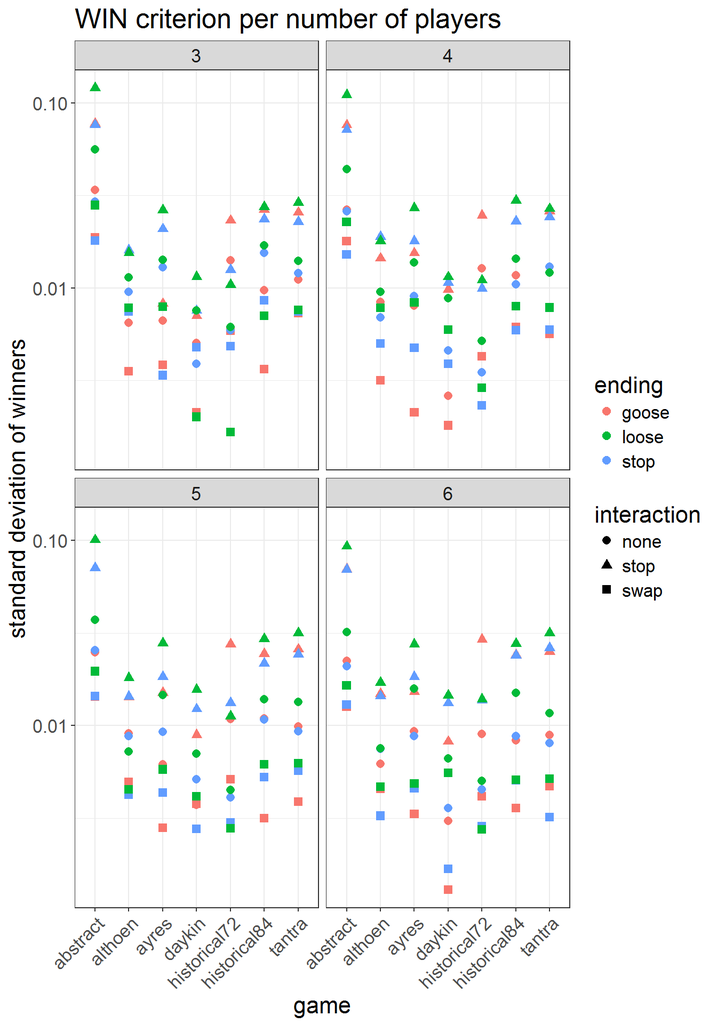

```r
d %>%
  rowwise() %>%
  mutate(win.sd = sd(c(winner1.perc, winner2.perc, winner3.perc,
                       winner4.perc, winner5.perc, winner6.perc), na.rm=TRUE)) %>%
  select(game, n.players, int.rule, end.rule, win.sd) %>%
  ggplot(aes(x=game, y=win.sd, shape=int.rule, colour=end.rule)) +
  geom_point(size=2.5) +
  scale_y_log10() +
  labs(x="game",y="standard deviation of winners", color="ending", shape="interaction",
       title="WIN criterion per number of players") +
  facet_wrap(~n.players) +
  theme_bw() +
  theme(text = element_text(size=16), axis.text.x = element_text(angle = 45, hjust = 1))
```

```r
# ggsave('WIN.pdf')
```

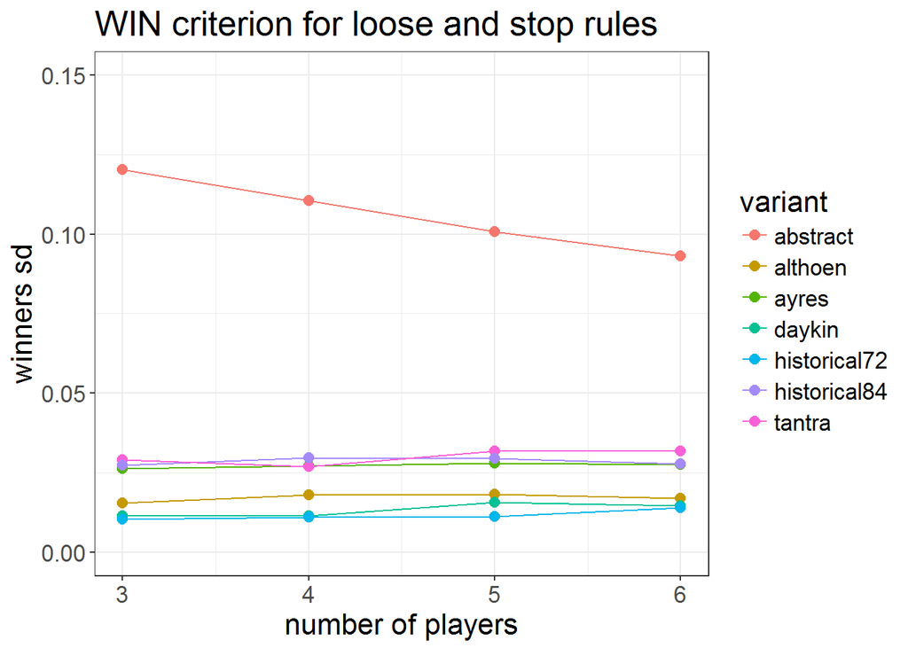

```r
d %>%
  rowwise() %>%
  dplyr::filter(int.rule=="stop", end.rule=="loose") %>%
  mutate(win.sd = sd(c(winner1.perc, winner2.perc, winner3.perc,
                       winner4.perc, winner5.perc, winner6.perc), na.rm=TRUE)) %>%
  select(game, n.players, int.rule, end.rule, win.sd) %>%
  ggplot(aes(x=n.players, y=win.sd, colour=game)) +
  geom_line() +
  geom_point(size=2.5) +
  ylim(0,0.15) +
  labs(x="number of players",y="winners sd", color="variant",
       title="WIN criterion for loose and stop rules") +
  theme_bw() +
  theme(text = element_text(size=16))
```

## WIN percentage

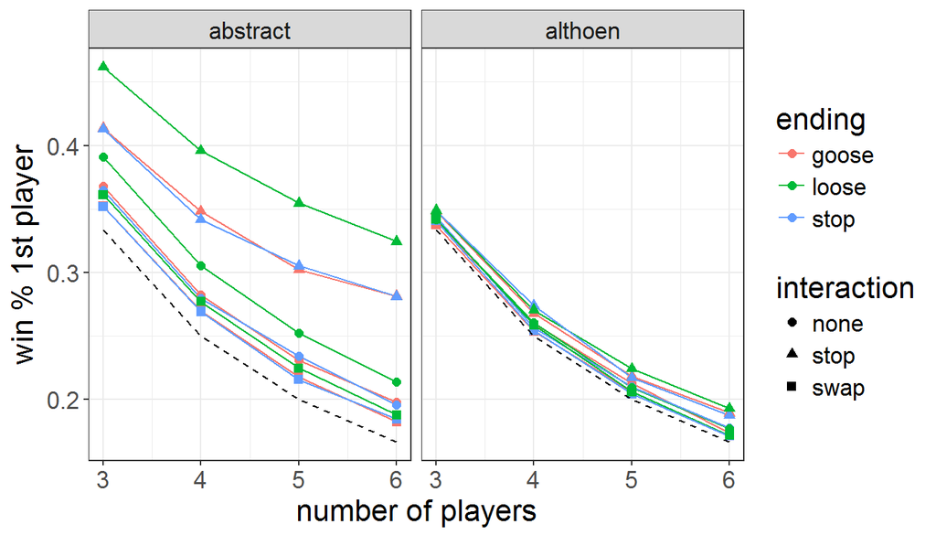

```r
ideal.percentages <- data.frame(n.players=3:6, winner1.perc=1/3:6, int.rule="none")

d %>%
  select(game, n.players, int.rule, end.rule, matches("winner")) %>%
  dplyr::filter(game=="abstract" | game=="althoen") %>%
  ggplot(aes(x=n.players, y=winner1.perc, shape=int.rule, colour=end.rule)) +
  geom_line() +
  geom_point(size=2) +
  geom_line(data=ideal.percentages, color="black", linetype="dashed") +
  #scale_y_log10() +
  labs(x="number of players",y="win % 1st player",
       color="ending", shape="interaction") +
  facet_wrap(~game) +
  theme_bw() +
  theme(text = element_text(size=16))
```

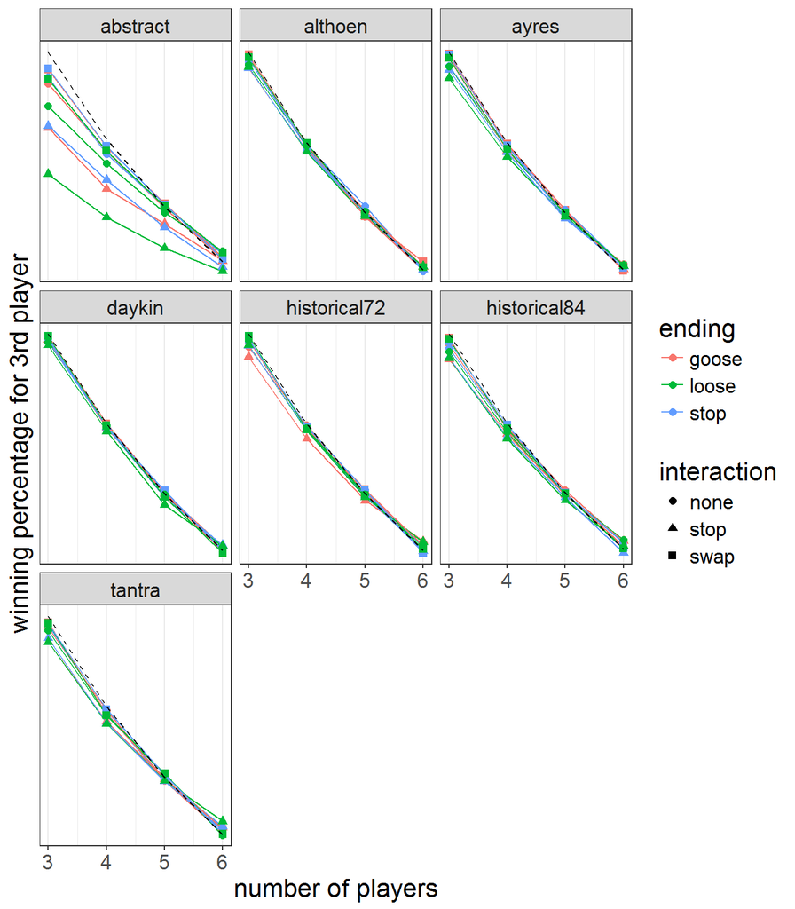

```r
ideal.percentages <- data.frame(n.players=3:6, winner3.perc=1/3:6, int.rule="none")

d %>%
  select(game, n.players, int.rule, end.rule, matches("winner")) %>%
  ggplot(aes(x=n.players, y=winner3.perc, shape=int.rule, colour=end.rule)) +
  geom_line() +
  geom_point(size=2) +
  geom_line(data=ideal.percentages, color="black", linetype="dashed") +
  scale_y_log10() +
  labs(x="number of players",y="winning percentage for 3rd player",
       color="ending", shape="interaction") +
  facet_wrap(~game, scales = "free_y") +
  theme_bw() +
  theme(text = element_text(size=16))
```

The 6th player can only be visualized for 6 player games, and so we lose one dimension:

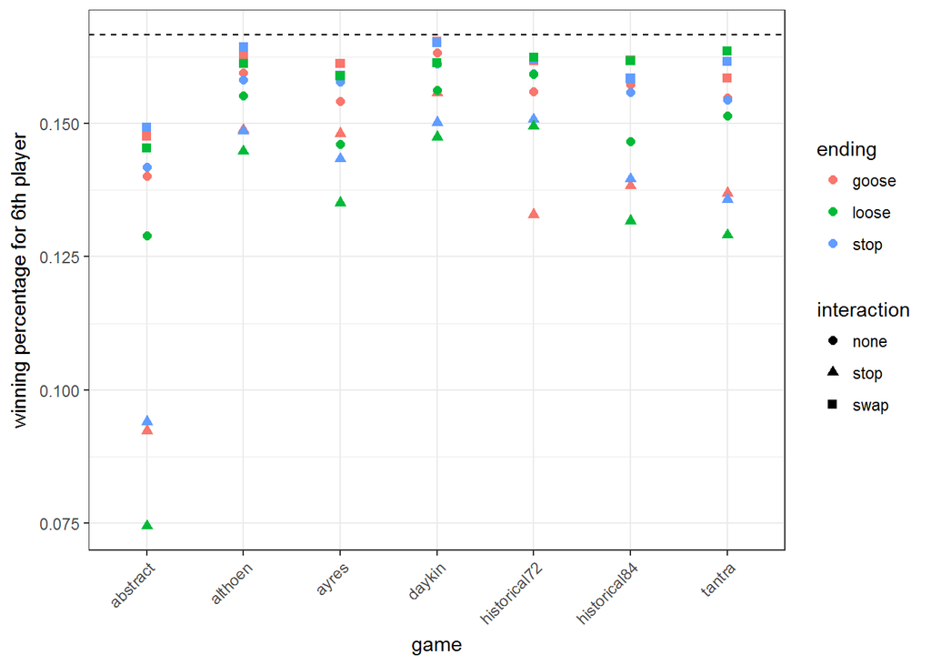

```r
d %>%
  dplyr::filter(!is.na(winner6.perc)) %>%
  select(game, n.players, int.rule, end.rule, winner6.perc) %>%
  ggplot(aes(x=game, y=winner6.perc, shape=int.rule, colour=end.rule)) +
  geom_point(size=2) +
  geom_hline(yintercept = 1/6, linetype="dashed") +
  labs(x="game",y="winning percentage for 6th player",
       color="ending", shape="interaction") +
  theme_bw() +
  theme(axis.text.x = element_text(angle = 45, hjust = 1))
```

## Testing the Uniformity Hypothesis

```r
library(knitr)
library(xtable)
```

```r
d %>%
  select(game, n.players, int.rule, end.rule, not.random) %>%
  dplyr::filter(not.random <= 0.95) %>%
  arrange(not.random) %>%
  kable()
```

| game | n.players | int.rule | end.rule | not.random |
| --- | --- | --- | --- | --- |
| daykin | 6 | swap | goose | 0.25 |
| historical72 | 3 | swap | loose | 0.36 |
| daykin | 6 | swap | stop | 0.42 |
| ayres | 4 | swap | goose | 0.47 |
| daykin | 4 | swap | goose | 0.47 |
| daykin | 3 | swap | loose | 0.50 |
| daykin | 3 | swap | goose | 0.54 |
| historical72 | 4 | swap | stop | 0.59 |
| daykin | 4 | none | goose | 0.77 |
| althoen | 3 | swap | goose | 0.83 |
| historical72 | 4 | swap | loose | 0.84 |
| ayres | 3 | swap | stop | 0.85 |
| ayres | 3 | swap | goose | 0.86 |
| historical84 | 3 | swap | goose | 0.88 |
| althoen | 4 | swap | goose | 0.89 |
| daykin | 5 | swap | stop | 0.89 |
| ayres | 5 | swap | goose | 0.92 |
| daykin | 3 | none | stop | 0.92 |
| daykin | 6 | none | goose | 0.93 |
| historical72 | 4 | none | stop | 0.93 |
| historical72 | 5 | swap | loose | 0.93 |
| historical72 | 5 | swap | stop | 0.94 |
| daykin | 3 | swap | stop | 0.95 |

```r
d %>%
  select(game, n.players, int.rule, end.rule, not.random) %>%
  dplyr::filter(not.random <= 0.95) %>%
  arrange(not.random) %>%
  xtable() %>%
  print(comment = FALSE)
```

## LEAD criterion

LEAD values state that a game is more dramatic if the player that wins did achieve the lead only a few turns before the end of the game.

We are just plotting the swap 6 player variants for presentation purposes (the different interaction rules and less number of players give similar results):

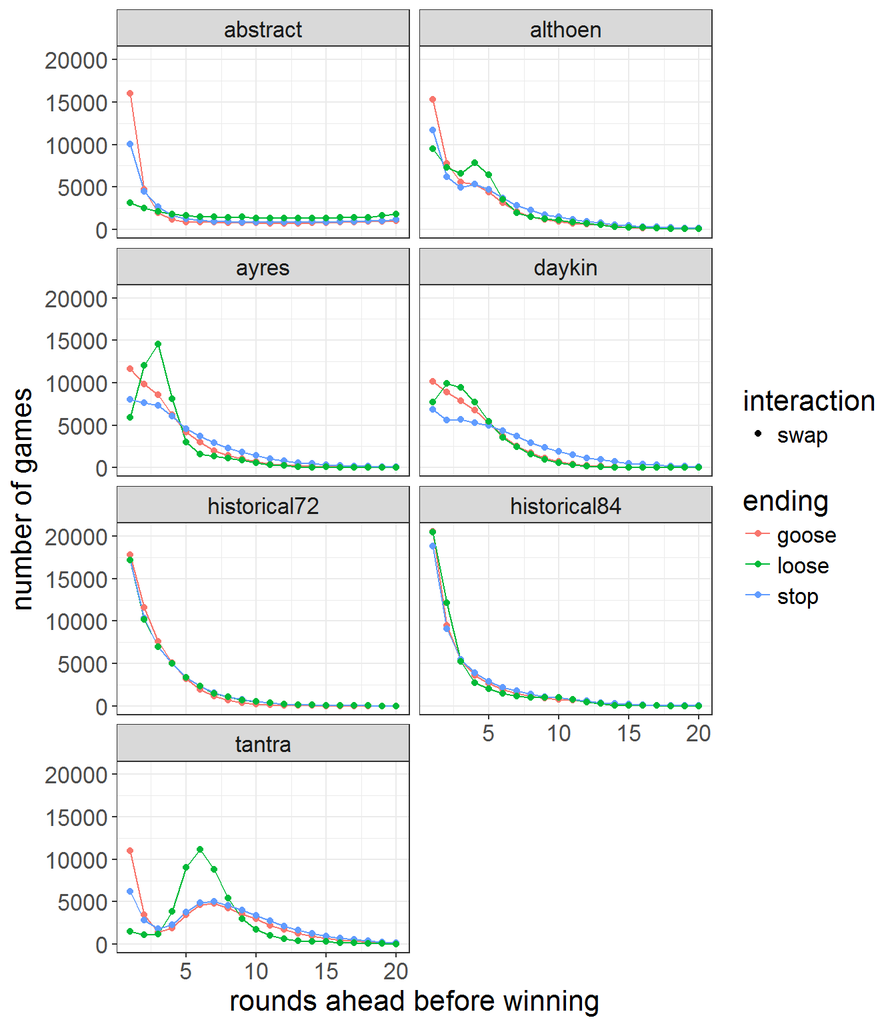

```r
d %>%
  select(game, n.players, int.rule, end.rule, matches("rounds")) %>%
  select(game, n.players, int.rule, end.rule, matches("persistence")) %>%
  dplyr::filter(n.players==6) %>%
  tidyr::gather("rounds", "n.games", 5:24) %>%
  dplyr::mutate(rounds = as.numeric(replace(rounds, 1:1260, rep(1:20,each=63)))) %>%
  dplyr::filter(int.rule=="swap") %>%
  ggplot(aes(x=rounds, y=n.games, shape=int.rule, colour=end.rule)) +
  geom_line() +
  geom_point(size=1.5) +
  labs(x="rounds ahead before winning",y="number of games",
       color="ending", shape="interaction") +
  facet_wrap(~game, ncol=2) +
  theme_bw() +
  theme(text = element_text(size=16))
```

## ANP criterion

The ANP criterion focus on the number of different players that were ahead during a game. The argument is that a game is more dramatic the more players are able to take the lead.

For visualization purposes we just show for the goose ending rule:

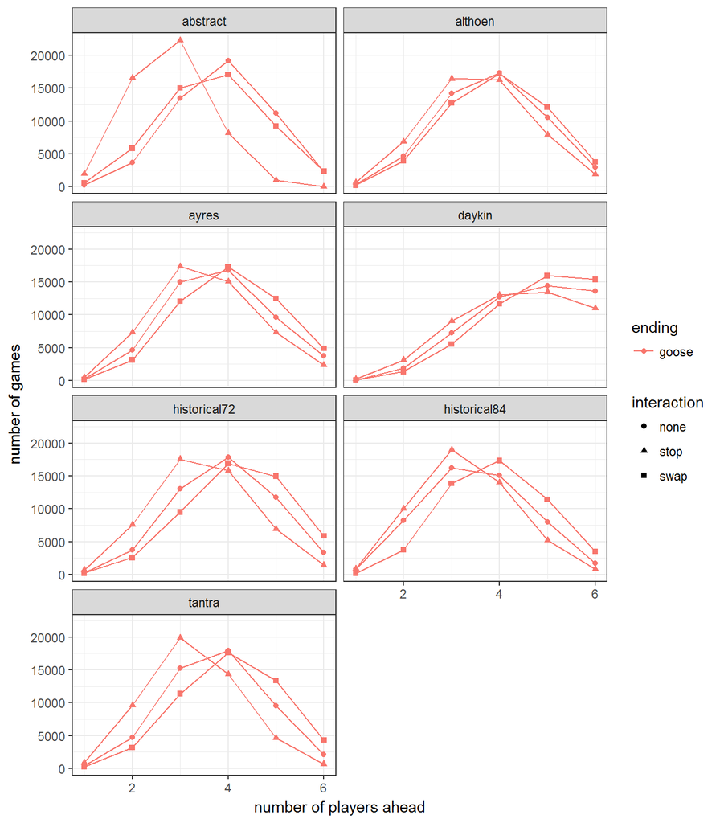

```r
d %>%
  dplyr::filter(n.players==6) %>%
  select(game, int.rule, end.rule, matches("players.ahead")) %>%
  tidyr::gather("ahead", "total", 4:9) %>%
  dplyr::mutate(ahead = as.numeric(replace(ahead, 1:378, rep(1:6,each=63)))) %>%
  dplyr::filter(end.rule=="goose") %>%
  ggplot(aes(x=ahead, y=total, shape=int.rule, colour=end.rule)) +
  geom_line() +
  geom_point(size=1.5) +
  labs(x="number of players ahead",y="number of games",
       color="ending", shape="interaction") +
  facet_wrap(~game, ncol=2) +
  theme_bw()
```

The next diagram shows the number of rounds each player was ahead in the entire simulation (should be as balanced as possible):

```r
d %>%
  dplyr::filter(n.players==6) %>%
  select(game, int.rule, end.rule, matches("ahead")) %>%
  select(game, int.rule, end.rule, matches("mean"), matches("sd")) -> d2

d2 %>%
  select(-matches("sd")) %>%
  tidyr::gather("ahead", "mean", 4:9) %>%
  dplyr::mutate(ahead = as.numeric(replace(ahead, 1:378, rep(1:6,each=63)))) -> d2a

d2 %>%
  select(-matches("mean")) %>%
  tidyr::gather("ahead", "sd", 4:9) %>%
  dplyr::mutate(ahead = as.numeric(replace(ahead, 1:378, rep(1:6,each=63))))-> d2b

d2a %>%
  dplyr::inner_join(d2b) %>%
  dplyr::filter(end.rule == "stop") -> d3
```

We present just for one type of ending rule. This rule does not change the interaction during the game, and eases the visualization:

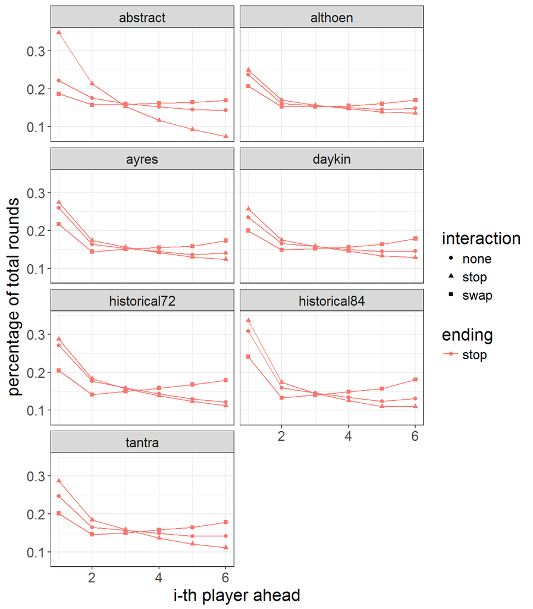

```r
ggplot(d3, aes(x=ahead, y=mean, shape=int.rule, colour=end.rule)) +
  geom_line() +
  geom_point(size=1.5) +
  # geom_errorbar(aes(ymin=mean-sd, ymax=mean+sd), width=.1) +
  labs(x="i-th player ahead",y="percentage of total rounds",
       color="ending", shape="interaction") +
  facet_wrap(~game, ncol=2) +
  theme_bw() +
  theme(text = element_text(size=16))
```

Notice however that the standard deviation is high, usually with the similar value as the mean itself.

## Game Length

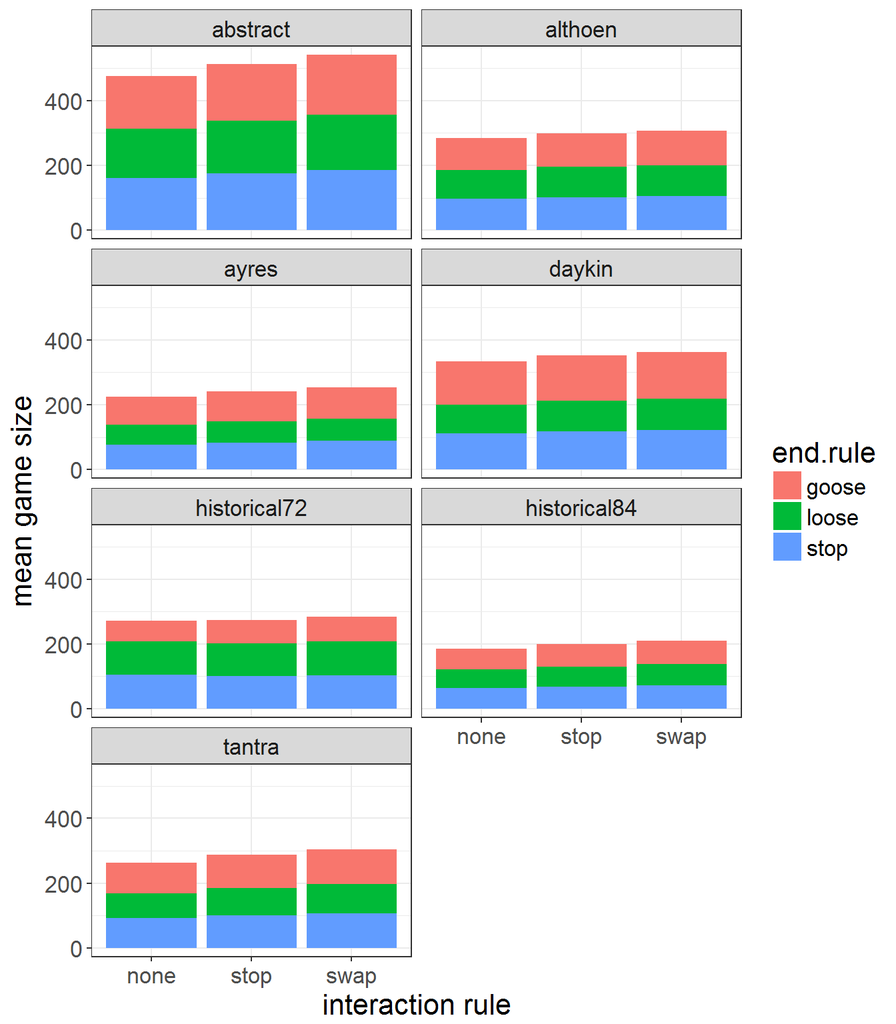

```r
d %>%
  dplyr::filter(n.players==6) %>%
  select(game, n.players, int.rule, end.rule, matches("moves")) %>%
  ggplot(aes(x=int.rule, y=moves.mean, fill=end.rule)) +
  geom_bar(stat = "identity") +
  labs(x="interaction rule",y="mean game size") +
  facet_wrap(~game, ncol=2) +
  theme_bw() +
  theme(text = element_text(size=16))
```

## Log-Normal fit

```r
best.fit <- d[which.max(d$lognorm.AIC),]

filename <- paste0(best.fit$game,"_",best.fit$n.players,"p_",
                   best.fit$int.rule,"_",best.fit$end.rule,"_50000.csv")
df <- read_csv2(paste0("../raw_data/",filename))[-1]

print(paste(best.fit$game,":",best.fit$n.players, "players with",
            best.fit$int.rule,"&", best.fit$end.rule,"rules"))
```

```
## [1] "daykin : 3 players with none & goose rules"
```

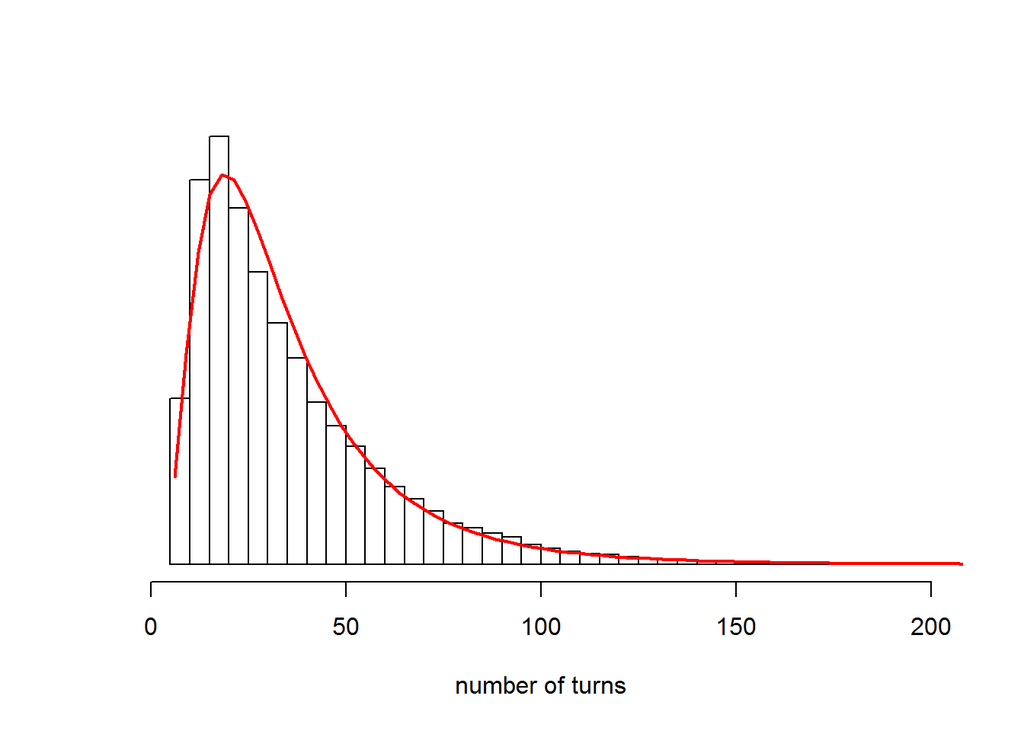

```r
res <- df$n.rounds
hist(res, breaks=50, ylab=NA, xlab="number of turns", prob=T, yaxt='n',xlim=c(0,200),
     main="", sub="")
xs  <- seq(min(res), max(res), len=100)
ys  <- dlnorm(xs, best.fit$lognorm.mean, best.fit$lognorm.sd)
points(xs,ys,type="l", col="red", lwd=2)
```

```r
worst.fit <- d[which.min(d$lognorm.AIC),]

filename <- paste0(worst.fit$game,"_",worst.fit$n.players,"p_",
                   worst.fit$int.rule,"_",worst.fit$end.rule,"_50000.csv")
df <- read_csv2(paste0("../raw_data/",filename))[-1]

print(paste(worst.fit$game,":",worst.fit$n.players, "players with",
            worst.fit$int.rule,"&", worst.fit$end.rule,"rules"))
```

```
## [1] "abstract : 6 players with none & loose rules"
```

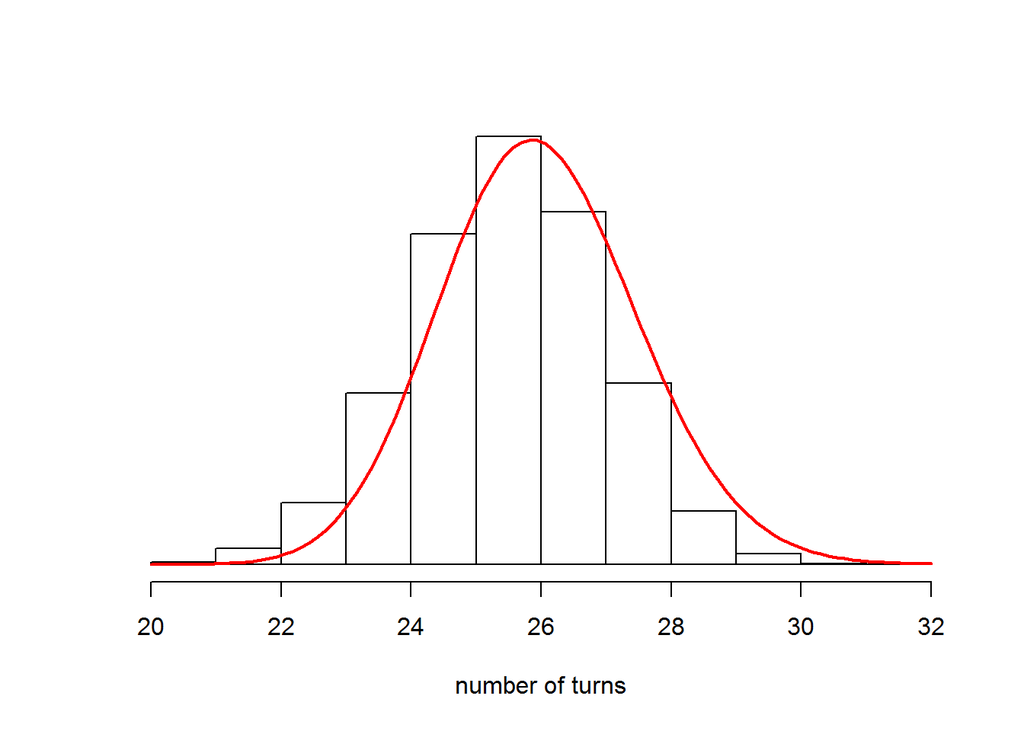

```r
res <- df$n.rounds
hist(res, breaks=15, ylab=NA, xlab="number of turns", prob=T, yaxt='n',
     main="", sub="")
xs  <- seq(min(res), max(res), len=100)
ys  <- dlnorm(xs, worst.fit$lognorm.mean, worst.fit$lognorm.sd)
points(xs,ys,type="l", col="red", lwd=2)
```

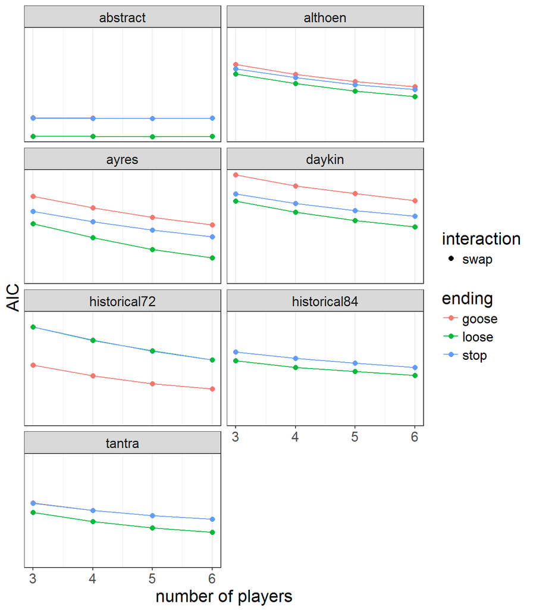

```r
d %>%
  select(game, n.players, int.rule, end.rule, matches("log")) %>%
  dplyr::filter(int.rule=="swap") %>%
  ggplot(aes(x=n.players, y=lognorm.AIC, shape=int.rule, colour=end.rule)) +
  geom_line() +
  geom_point(size=2) +
  labs(x="number of players",y="AIC",
       color="ending", shape="interaction") +
  scale_y_log10() +
  facet_wrap(~game, ncol=2) +
  theme_bw() +
  theme(text = element_text(size=16))
```

The values decrease with the number of players. This means player interaction together with the special cells, makes the game less predictable wrt to the lognormal model fit.

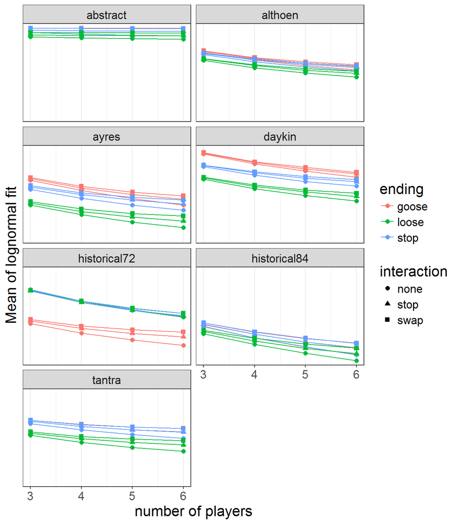

```r
d %>%
  select(game, n.players, int.rule, end.rule, matches("log")) %>%
  # dplyr::filter(int.rule=="swap") %>%
  ggplot(aes(x=n.players, y=lognorm.mean, shape=int.rule, colour=end.rule)) +
  geom_line() +
  geom_point(size=2) +
  labs(x="number of players",y="Mean of lognormal fit",
       color="ending", shape="interaction") +
  scale_y_log10() +
  facet_wrap(~game, ncol=2) +
  theme_bw() +
  theme(text = element_text(size=16))
```

This well-behaved lines are evidence that we can estimate the average mean and variance of these variants with more players.